# Test your multiplatform app − tutorial

In this tutorial, you'll learn how to create, configure, and run tests in Kotlin Multiplatform applications.

Tests for multiplatform projects can be divided into two categories:

- Tests for common code. These tests can be run on any platform using any supported framework.
- Tests for platform-specific code. These are essential to test platform-specific logic. They use a platform-specific framework and can benefit from its additional features, such as a richer API and a wider range of assertions.

Both categories are supported in multiplatform projects. This tutorial will first show you how to set up, create, and run unit tests for common code in a simple Kotlin Multiplatform project. Then, you'll work with a more complex example that requires tests both for common and platform-specific code.

## Test a simple multiplatform project

### Create a project

1. In the quickstart, complete the instructions to set up your environment for Kotlin Multiplatform development.
2. In IntelliJ IDEA, select File | New | Project.
3. In the panel on the left, select Kotlin Multiplatform.
4. Specify the following fields in the New Project window:
   - Name: KMP testing
   - Project ID: kmp.project.testing
5. Select the Android target. If you're using a Mac, select iOS as well. Make sure to select the Do not share UI option.
6. Deselect Include tests and click Create.

[figure not shown]

### Write code

In the `sharedLogic/src/commonMain/kotlin` directory, create a new `common.example.search` package. In this package, create a Kotlin file, `Grep.kt`, with the following function:

```
fun grep(lines: List<String>, pattern: String, action: (String) -> Unit) {
    val regex = pattern.toRegex()
    lines.filter(regex::containsMatchIn)
        .forEach(action)
}
```

This function is designed to resemble the [UNIX `grep` command](https://en.wikipedia.org/wiki/Grep). Here, the function takes lines of text, a pattern used as a regular expression, and a function that is invoked every time a line matches the pattern.

### Add tests

Now, let's test the common code. An essential part will be a source set for common tests, which has the [`kotlin.test`](https://kotlinlang.org/api/latest/kotlin.test/) API library as a dependency.

1. In the `sharedLogic/build.gradle.kts` file, check that there is a dependency on the `kotlin.test` library:

   ```
   sourceSets {
      //...
      commonTest.dependencies {
          implementation(libs.kotlin.test)
      }
   }
   ```

2. The `commonTest` source set stores all common tests. You need to create a directory with the same name in your project:
   1. Right-click the `sharedLogic/src` directory and select New | Directory. The IDE presents a list of options.
   2. Start typing the `commonTest/kotlin` path to narrow down the selection, then choose it from the list:

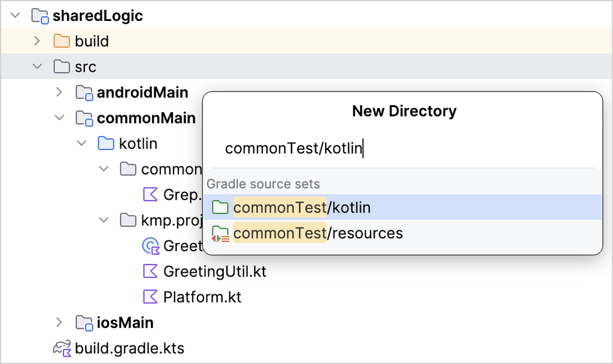

3. In the `commonTest/kotlin` directory, create a new `common.example.search` package.
4. In this package, create the `Grep.kt` file and update it with the following unit test:

   ```
   import kotlin.test.Test
   import kotlin.test.assertContains
   import kotlin.test.assertEquals

   class GrepTest {
       companion object {
           val sampleData = listOf(
               "123 abc",
               "abc 123",
               "123 ABC",
               "ABC 123"
           )
       }

       @Test
       fun shouldFindMatches() {
           val results = mutableListOf<String>()
           grep(sampleData, "[a-z]+") {
               results.add(it)
           }

           assertEquals(2, results.size)
           for (result in results) {
               assertContains(result, "abc")
           }
       }
   }
   ```

As you can see, imported annotations and assertions are neither platform- nor framework-specific. When you run this test later, a platform-specific framework will provide the test runner.

#### Explore the `kotlin.test` API

The [`kotlin.test`](https://kotlinlang.org/api/latest/kotlin.test/) library provides platform-agnostic annotations and assertions for you to use in your tests. Annotations, such as `Test`, map to those provided by the selected framework or their nearest equivalent.

Assertions are executed through an implementation of the [`Asserter` interface](https://kotlinlang.org/api/latest/kotlin.test/kotlin.test/-asserter/). This interface defines the different checks commonly performed in testing. The API has a default implementation, but typically you will use a framework-specific implementation.

For example, the JUnit 4, JUnit 5, and TestNG frameworks are all supported on JVM. On Android, a call to `assertEquals()` might result in a call to `asserter.assertEquals()`, where the `asserter` object is an instance of `JUnit4Asserter`. On iOS, the default implementation of the `Asserter` type is used in conjunction with the Kotlin/Native test runner.

### Run tests

You can execute the test by running:

- The `shouldFindMatches()` test function using the Run icon in the gutter.
- The test file using its context menu.
- The `GrepTest` test class using the Run icon in the gutter.

There's also a handy `⌃ ⇧ F10`/`Ctrl+Shift+F10` shortcut. Regardless of the option you choose, you'll see a list of targets to run the test on:

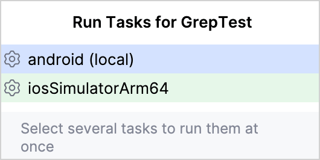

For the `android` option, tests are run using JUnit 4. For `iosSimulatorArm64`, the Kotlin compiler detects testing annotations and creates a test binary that is executed by Kotlin/Native's own test runner.

Here is an example of the output generated by a successful test run:

[figure not shown]

## Work with more complex projects

### Write tests for common code

You've already created a test for common code with the `grep()` function. Now, let's consider a more advanced common code test with the `CurrentRuntime` class. This class contains details of the platform on which the code is executed. For example, it might have the values "OpenJDK" and "17.0" for Android unit tests that run on a local JVM.

An instance of `CurrentRuntime` should be created with the name and version of the platform as strings, where the version is optional. When the version is present, you only need the number at the start of the string, if available.

1. In the `commonMain/kotlin` directory, create a new `org.kmp.testing` package.
2. In this package, create the `CurrentRuntime.kt` file and update it with the following implementation:

   ```
   class CurrentRuntime(val name: String, rawVersion: String?) {
       companion object {
           val versionRegex = Regex("^[0-9]+(\\.[0-9]+)?")
       }

       val version = parseVersion(rawVersion)

       override fun toString() = "$name version $version"

       private fun parseVersion(rawVersion: String?): String {
           val result = rawVersion?.let { versionRegex.find(it) }
           return result?.value ?: "unknown"
       }
   }
   ```

3. In the `commonTest/kotlin` directory, create a new `org.kmp.testing` package.
4. In this package, create the `CurrentRuntimeTest.kt` file and update it with the following platform and framework-agnostic test:

   ```
   import kotlin.test.Test
   import kotlin.test.assertEquals

   class CurrentRuntimeTest {
       @Test
       fun shouldDisplayDetails() {
           val runtime = CurrentRuntime("MyRuntime", "1.1")
           assertEquals("MyRuntime version 1.1", runtime.toString())
       }

       @Test
       fun shouldHandleNullVersion() {
           val runtime = CurrentRuntime("MyRuntime", null)
           assertEquals("MyRuntime version unknown", runtime.toString())
       }

       @Test
       fun shouldParseNumberFromVersionString() {
           val runtime = CurrentRuntime("MyRuntime", "1.2 Alpha Experimental")
           assertEquals("MyRuntime version 1.2", runtime.toString())
       }

       @Test
       fun shouldHandleMissingVersion() {
           val runtime = CurrentRuntime("MyRuntime", "Alpha Experimental")
           assertEquals("MyRuntime version unknown", runtime.toString())
       }
   }
   ```

You can run this test using any of the ways available in the IDE.

### Add platform-specific tests

Now you have experience writing tests for common code, let's explore writing platform-specific tests for Android and iOS.

To create an instance of `CurrentRuntime`, declare a function in the common `CurrentRuntime.kt` file as follows:

```
expect fun determineCurrentRuntime(): CurrentRuntime
```

The function should have separate implementations for each supported platform. Otherwise, the build will fail. As well as implementing this function on each platform, you should provide tests. Let's create them for Android and iOS.

#### For Android

1. In the `androidMain/kotlin` directory, create a new `org.kmp.testing` package.
2. In this package, create the `AndroidRuntime.kt` file and update it with the actual implementation of the expected `determineCurrentRuntime()` function:

   ```
   actual fun determineCurrentRuntime(): CurrentRuntime {
       val name = System.getProperty("java.vm.name") ?: "Android"

       val version = System.getProperty("java.version")

       return CurrentRuntime(name, version)
   }
   ```

3. Create a directory for tests inside the `sharedLogic/src` directory:
   1. Right-click the `sharedLogic/src` directory and select New | Directory. The IDE presents a list of options.
   2. Start typing the `androidHostTest/kotlin` path to narrow down the selection, then choose it from the list:

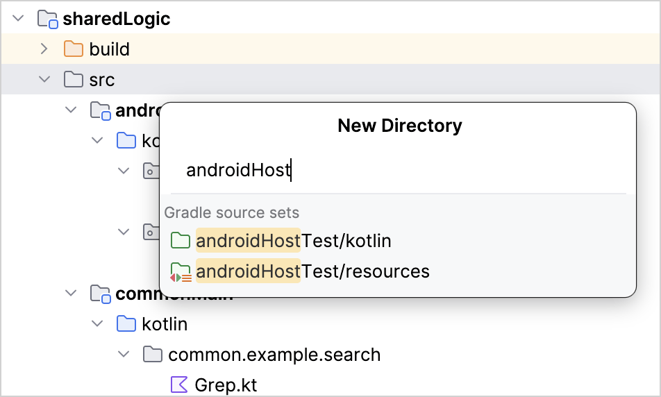

4. In the `androidHostTest/kotlin` directory, create a new `org.kmp.testing` package.
5. In this package, create the `AndroidRuntimeTest.kt` file and update it with the following Android test. To make the test pass, make sure to set the actual name and version of the runtime (but it is also useful to see how a test fails):

   ```
   import kotlin.test.Test
   import kotlin.test.assertContains
   import kotlin.test.assertEquals

   class AndroidRuntimeTest {
       @Test
       fun shouldDetectAndroid() {
           val runtime = determineCurrentRuntime()
           assertContains(runtime.name, "OpenJDK")
           assertEquals(runtime.version, "21.0")
       }
   }
   ```

It may seem strange that an Android-specific test is run on a local JVM. This is because these tests run as local unit tests on the current machine. As described in the [Android Studio documentation](https://developer.android.com/studio/test/test-in-android-studio), these tests differ from instrumented tests, which run on a device or an emulator.

You can add other types of tests to your project. To learn about instrumented tests, see this [Touchlab guide](https://touchlab.co/understanding-and-configuring-your-kmm-test-suite/).

#### For iOS

1. In the `iosMain/kotlin` directory, create a new `org.kmp.testing` directory.
2. In this directory, create the `IOSRuntime.kt` file and update it with the actual implementation of the expected `determineCurrentRuntime()` function:

   ```
   import kotlin.experimental.ExperimentalNativeApi
   import kotlin.native.Platform

   @OptIn(ExperimentalNativeApi::class)
   actual fun determineCurrentRuntime(): CurrentRuntime {
       val name = Platform.osFamily.name.lowercase()
       return CurrentRuntime(name, null)
   }
   ```

   ```
   import kotlin.test.Test
   import kotlin.test.assertEquals

   class IOSRuntimeTest {
       @Test
       fun shouldDetectOS() {
           val runtime = determineCurrentRuntime()
           assertEquals(runtime.name, "ios")
           assertEquals(runtime.version, "unknown")
       }
   }
   ```

### Run multiple tests and analyze reports

At this stage, you have the code for common, Android, and iOS implementations, as well as their tests. The directory structure in your project should look something like this:

[figure not shown]

You can run individual tests from the context menu or use the shortcut. One more option is to use Gradle tasks. For example, if you run the `allTests` Gradle task, every test in your project will be run with the corresponding test runner:

[figure not shown]

When you run tests, in addition to the output in your IDE, HTML reports are generated. You can find them in the `sharedLogic/build/reports/tests` directory:

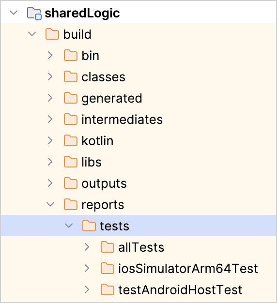

Run the `allTests` task and examine the reports it generated:

[figure not shown]

## Rules for using tests in multiplatform projects

You've now created, configured, and executed tests in Kotlin Multiplatform applications. When working with tests in your future projects, remember:

- When writing tests for common code, use only multiplatform libraries, like [kotlin.test](https://kotlinlang.org/api/latest/kotlin.test/). Add dependencies to the `commonTest` source set.
- The `Asserter` type from the `kotlin.test` API should only be used indirectly. Although the `Asserter` instance is visible, you don't need to use it in your tests.
- Always stay within the testing library API. Fortunately, the compiler and the IDE prevent you from using framework-specific functionality.
- Although it doesn't matter which framework you use for running tests in `commonTest`, it's a good idea to run your tests with each framework you intend to use to check that your development environment is set up correctly.
- Consider the physics difference. For example, scrolling inertia and friction values vary by platform and device, so setting the same scrolling speed may result in different scroll positions. Always test your components on the target platform to ensure the expected behavior.
- When writing tests for platform-specific code, you can use the functionality of the corresponding framework, for example, annotations and extensions.
- You can run tests both from the IDE and using Gradle tasks.
- When you run tests, HTML test reports are generated automatically.

## What's next?

- Explore the layout of multiplatform projects in Understand Multiplatform project structure.
- Check out [Kotest](https://kotest.io/), another multiplatform testing framework provided by the Kotlin ecosystem. Kotest allows writing tests in a range of styles and supports complementary approaches to regular testing. These include [data-driven](https://kotest.io/docs/framework/datatesting/data-driven-testing.html) and [property-based](https://kotest.io/docs/proptest/property-based-testing.html) testing.

15 May 2026

© 2010–2026 JetBrains s.r.o. and Kotlin Programming Language contributors  
Licensed under the Apache License, Version 2.0.  
https://kotlinlang.org/docs/multiplatform/multiplatform-run-tests.html